# INLA

2025-10-28

## INLA

O algoritmo INLA está implementado no R no pacote INLA

Detalhes sobre instalação: https://www.r-inla.org

### Regressão Linear

O conjunto de dados é conhecido como USairpollution e contém a concentração média anual de dióxido de enxofre, em microgramas por metro cúbico, uma medida da poluição do ar da cidade.

O data frame com 41 observações sobre as seguintes 7 variáveis:

- **SO2**: teor de dióxido de enxofre no ar, em microgramas por metro cúbico.
- **temp**: temperatura média anual em graus Fahrenheit.
- **manu**: número de indústrias manufatureiras com 20 ou mais empregados.
- **popul**: tamanho da população (censo de 1970), em milhares.
- **wind**: velocidade média anual do vento, em milhas por hora.
- **precip**: precipitação média anual, em polegadas.
- **predays**: número médio de dias com precipitação por ano.

```
##             SO2 temp manu popul wind precip predays
## Albany       46 47.6   44   116  8.8  33.36     135
## Albuquerque  11 56.8   46   244  8.9   7.77      58
## Atlanta      24 61.5  368   497  9.1  48.34     115
## Baltimore    47 55.0  625   905  9.6  41.31     111
## Buffalo      11 47.1  391   463 12.4  36.11     166
## Charleston   31 55.2   35    71  6.5  40.75     148
```

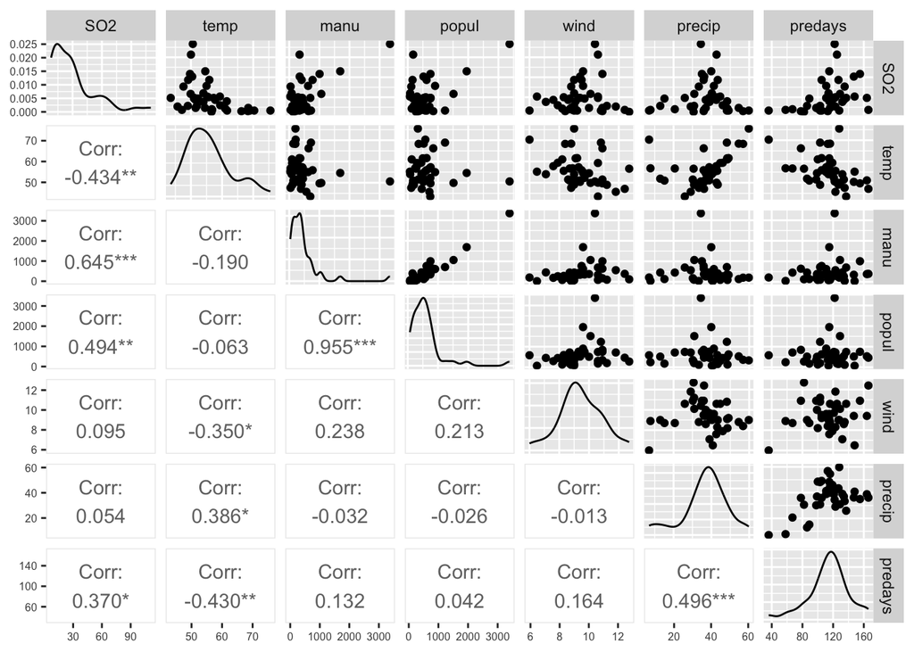

```r
library(INLA)
usair.formula1 <- SO2 ~ temp + manu + wind + precip + predays
usair.inla1 <- inla(usair.formula1, data = USairpollution, control.compute=list(waic = TRUE, cpo = TRUE))
```

```r
summary(usair.inla1)
```

```
## Time used:
##     Pre = 0.806, Running = 0.357, Post = 0.0162, Total = 1.18
## Fixed effects:
##                mean     sd 0.025quant 0.5quant 0.975quant    mode kld
## (Intercept) 135.492 49.774     37.334  135.500    233.606 135.500   0
## temp         -1.769  0.633     -3.017   -1.769     -0.520  -1.769   0
## manu          0.026  0.005      0.017    0.026      0.035   0.026   0
## wind         -3.723  1.931     -7.529   -3.723      0.086  -3.723   0
## precip        0.625  0.387     -0.137    0.625      1.387   0.625   0
## predays      -0.057  0.174     -0.399   -0.057      0.286  -0.057   0
##
## Model hyperparameters:
##                                          mean    sd 0.025quant 0.5quant
## Precision for the Gaussian observations 0.004 0.001      0.003    0.004
##                                         0.975quant  mode
## Precision for the Gaussian observations      0.006 0.004
##
## Watanabe-Akaike information criterion (WAIC) ...: 352.75
## Effective number of parameters .................: 7.82
##
## Marginal log-Likelihood:  -208.73
## CPO, PIT is computed
## Posterior summaries for the linear predictor and the fitted values are computed
## (Posterior marginals needs also 'control.compute=list(return.marginals.predictor=TRUE)')
```

Alguns outros resultados disponíveis pelo INLA.

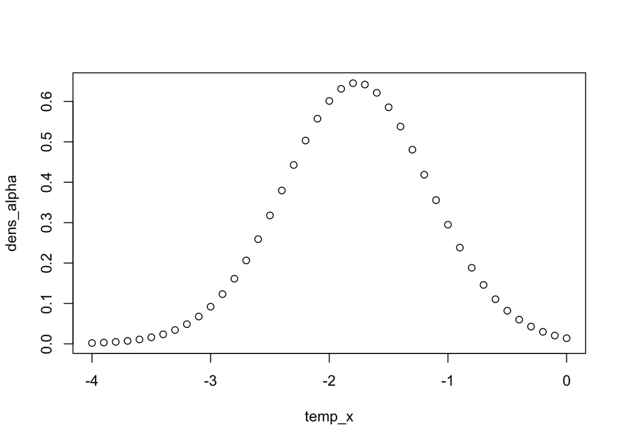

```r
#usair.inla1$summary.linear.predictor #medidas das distribuicoes a posteriori dos preditores lineares
#usair.inla1$marginals.fixed$temp

marginal_alpha <- usair.inla1$marginals.fixed[["temp"]]
temp_x = seq(-4,0,0.1)
# Transformando em função de densidade
dens_alpha <- inla.dmarginal(temp_x,marginal = marginal_alpha)
plot(temp_x, dens_alpha)
```

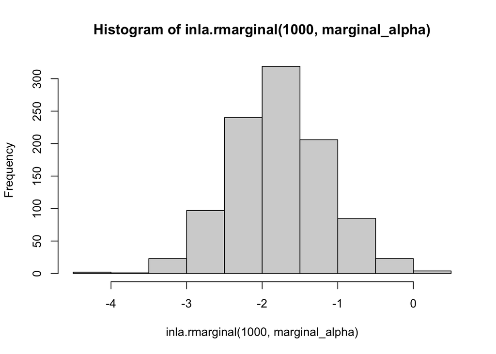

```r
hist(inla.rmarginal(1000,marginal_alpha))
```

```r
inla.emarginal(fun = function(x) x, marg = marginal_alpha)
```

```
## [1] -1.768998
```

```r
#usair.inla1$summary.hyperpar #medidas das distribuicoes a psoteriori dos hyperprameteros
#usair.inla1$marginals.hyperpar
#usair.inla1$waic$waic
#usair.inla1$cpu.used

#usair.inla1$cpo$pit
```

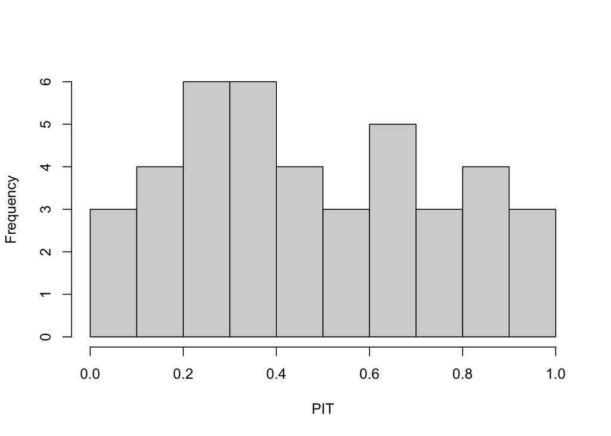

```r
hist(usair.inla1$cpo$pit, main="", breaks = 10, xlab = "PIT")
```

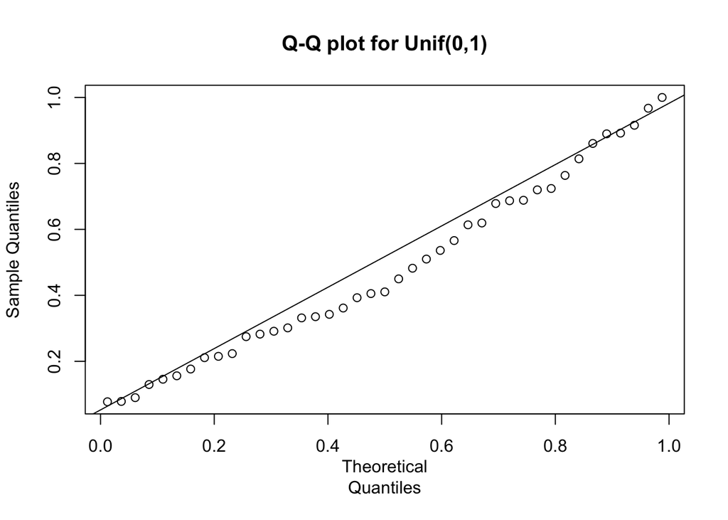

```r
qqplot(qunif(ppoints(length(usair.inla1$cpo$pit))), usair.inla1$cpo$pit, main = "Q-Q plot for Unif(0,1)", xlab = "Theoretical
Quantiles", ylab = "Sample Quantiles")
qqline(usair.inla1$cpo$pit, distribution = function(p) qunif(p), prob = c(0.1,0.9))
```

```r
LPML3 <- sum(log(usair.inla1$cpo$cpo))
```

#### Dados longitudinais com modelo aleatorio

Em Singer e Willett (2003), são apresentados os escores de leitura no teste Peabody Individual Achievement Test (PIAT) para 89 crianças, medidos nas idades de 6,5, 8,5 e 10,5 anos.

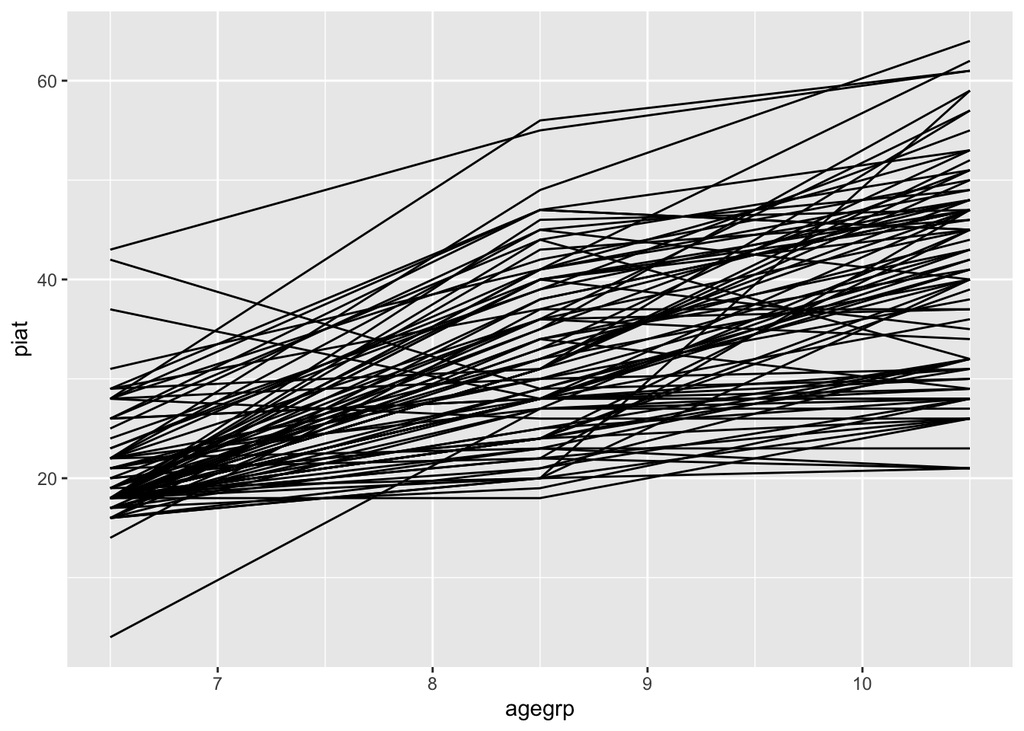

```r
#remotes::install_github("julianfaraway/brinla")
library(brinla)
data(reading)
ggplot(reading, aes(agegrp, piat, group=id)) + geom_line()
```

```r
sample_ids <- sample(unique(reading$id), 12)


library(dplyr)
```

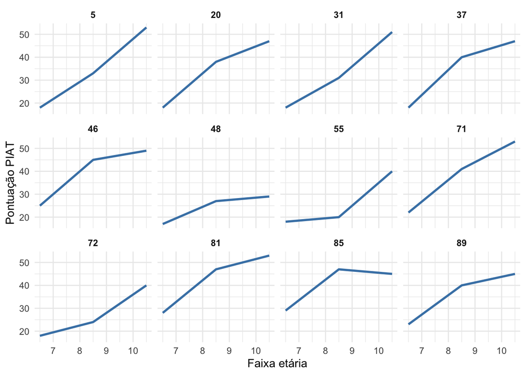

```r
reading_subset <- reading %>%
  filter(id %in% sample_ids)

ggplot(reading_subset, aes(x = agegrp, y = piat, group = id)) +
  geom_line(color = "steelblue", size = 1) +
  #geom_point(color = "black", size = 2) +
  facet_wrap(~id, ncol = 4) +   # organiza em matriz: 4 colunas
  labs(x = "Faixa etária", y = "Pontuação PIAT") +
  theme_minimal() +
  theme(strip.text = element_text(face = "bold"))
```

**Random Intercept model**

O modelo considerado é dado por:

$$y_{ij} = \beta_0 + \beta_1 t_j + \alpha_i + \varepsilon_{ij}, \quad i =
1, \ldots, 89; \quad j = 1, 2, 3.$$

O tempo (ou idade, neste exemplo) é medido em três ocasiões: $t_1, t_2, t_3$.

Os parâmetros $\beta_0$ e $\beta_1$ são os chamados **efeitos fixos**, representando o intercepto e a inclinação comuns a todos os estudantes.  
Para esses parâmetros, assume-se uma **prior gaussiana**.

Os componentes aleatórios são dados por:

$$\alpha_i \sim \mathcal{N}(0, \sigma^2_{\alpha}) \quad \text{e} \quad
\varepsilon_{ij} \sim \mathcal{N}(0, \sigma^2_{\varepsilon}).$$

Os hiperparâmetros $\sigma^2_{\alpha}$ e $\sigma^2_{\varepsilon}$ requerem a especificação de distribuições a priori.

```r
reading$cagegrp = reading$agegrp - mean(reading$agegrp)
formula <- piat ~ agegrp + f(id, model="iid")
imod <- inla(formula, family="gaussian", data=reading)
summary(imod)
```

```
## Time used:
##     Pre = 0.77, Running = 0.233, Post = 0.00875, Total = 1.01
## Fixed effects:
##                mean    sd 0.025quant 0.5quant 0.975quant    mode kld
## (Intercept) -11.535 2.256    -15.962  -11.535     -7.108 -11.535   0
## agegrp        5.031 0.252      4.536    5.031      5.526   5.031   0
##
## Random effects:
##   Name     Model
##     id IID model
##
## Model hyperparameters:
##                                          mean    sd 0.025quant 0.5quant
## Precision for the Gaussian observations 0.022 0.002      0.018    0.022
## Precision for id                        0.037 0.009      0.023    0.036
##                                         0.975quant  mode
## Precision for the Gaussian observations      0.027 0.022
## Precision for id                             0.057 0.033
##
## Marginal log-Likelihood:  -967.59
##  is computed
## Posterior summaries for the linear predictor and the fitted values are computed
## (Posterior marginals needs also 'control.compute=list(return.marginals.predictor=TRUE)')
```

```r
sigma_alpha = imod$marginals.hyperpar$`Precision for id`
E_sigma = inla.emarginal(fun = function(x) 1/sqrt(x), marg = sigma_alpha)
den_hyper = inla.tmarginal(fun = function(x) 1/sqrt(x), marg = sigma_alpha)
```

```r
imod$summary.random
```

```
## $id
##    ID        mean       sd  0.025quant    0.5quant  0.975quant        mode
## 1   1  3.95981931 3.176359  -2.2497304  3.95143149 10.21603602  3.95113279
## 2   2 -4.89938484 3.188783 -11.1832046 -4.88964686  1.32995907 -4.88936761
## 3   3 -4.46723406 3.182747 -10.7378474 -4.45807306  1.75226791 -4.45777906
## 4   4  1.15080442 3.154820  -5.0337513  1.14809835  7.35027783  1.14797161
## 5   5  2.23119864 3.160316  -3.9570933  2.22608668  8.44773674  2.22586148
## 6   6 -3.60292847 3.172320  -9.8497513 -3.59514144  2.60064569 -3.59484719
## 7   7 -4.46723406 3.182747 -10.7378474 -4.45807306  1.75226791 -4.45777906
## 8   8 -1.44214700 3.155957  -7.6456135 -1.43877392  4.74271586 -1.43861787
## 9   9 -2.95469625 3.165949  -9.1860387 -2.94810767  3.24015359 -2.94783655
## 10 10 -7.92439179 3.246074 -14.3236523 -7.91314429 -1.58984466 -7.91325381
## 11 11 -1.22606794 3.155089  -7.4265292 -1.22318853  4.95851822 -1.22305406
## 12 12  2.66335521 3.163493  -3.5284550  2.65734534  8.88841787  2.65709037
## 13 13  3.09551093 3.167227  -3.1010028  3.08865111  9.33004041  3.08837341
```

[output cut: 166 more lines]

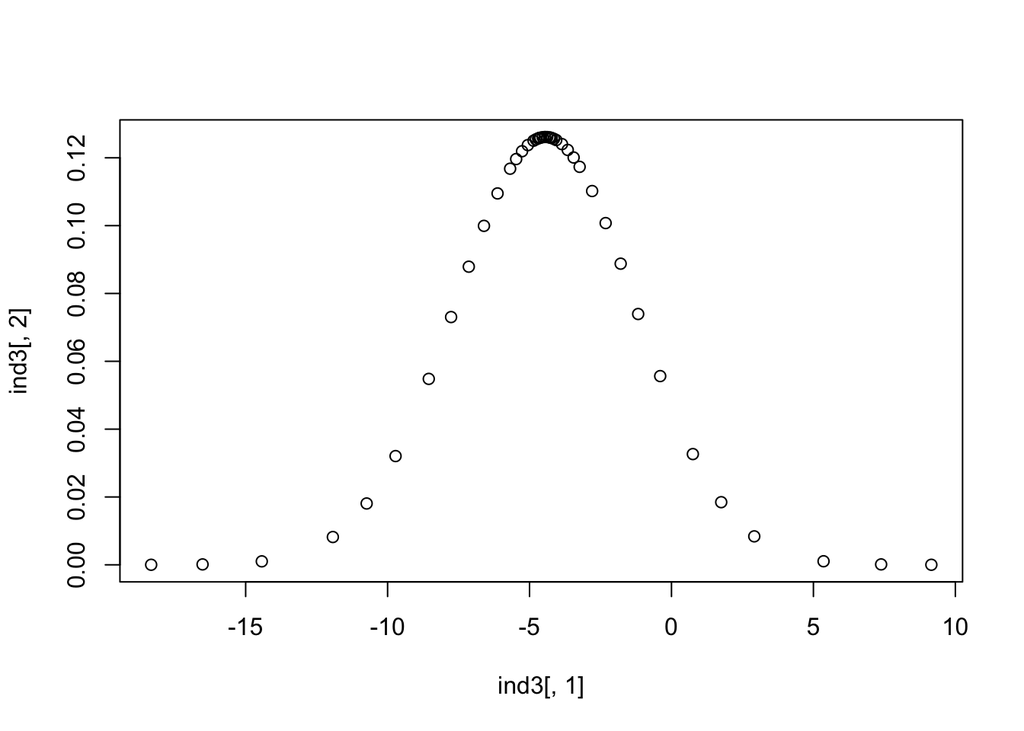

```r
ind3 = imod$marginals.random$id$index.3

plot(ind3[,1],ind3[,2])
```